# Métodos Cuantitativos II

v. 2026.03.19

PDF

## Introducción

## Estacionariedad (1/4)

Recordemos que para que una serie de tiempo, \(y_t\), sea estacionaria (en covarianza), es necesario que:

- Su media y varianza sean constantes. Esto es, para todo \(t\in\mathbb{Z}\):

\[ \begin{align} \mathbb{E}(y_t) &= \mu;\\ \mathbb{V}ar(y_t)&= \gamma_0<\infty \end{align} \]

- Su función de autocovarianza dependa solo del desfase \(h\) y no del tiempo \(t\):

\[ \gamma(t,\tau) = \gamma(h); \ h=|t-\tau| \ \in \mathbb{Z} \]

## Estacionariedad (2/4)

Las siguientes series de tiempo podrían ser estacionarias:

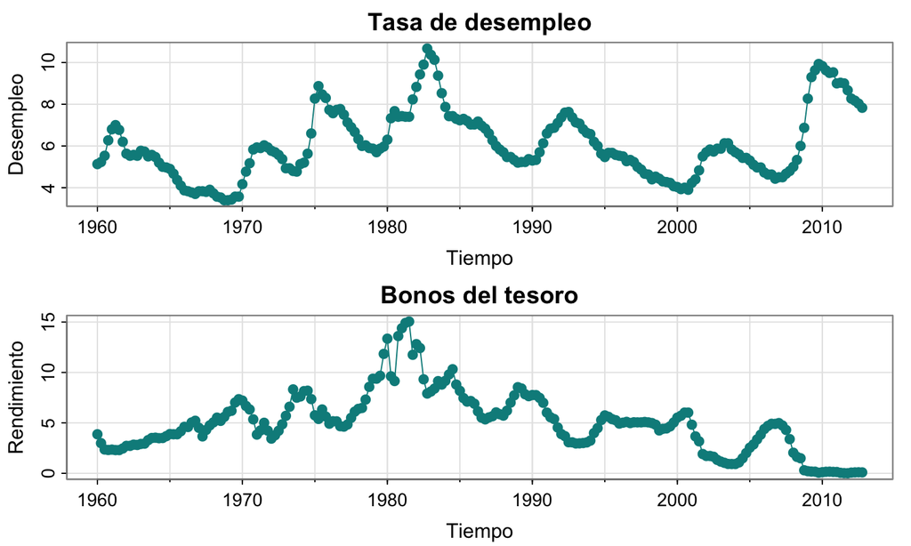

## Estacionariedad (3/4)

¿Qué pasa si las series de tiempo presentan un **patrón estacional**? Por ejemplo:

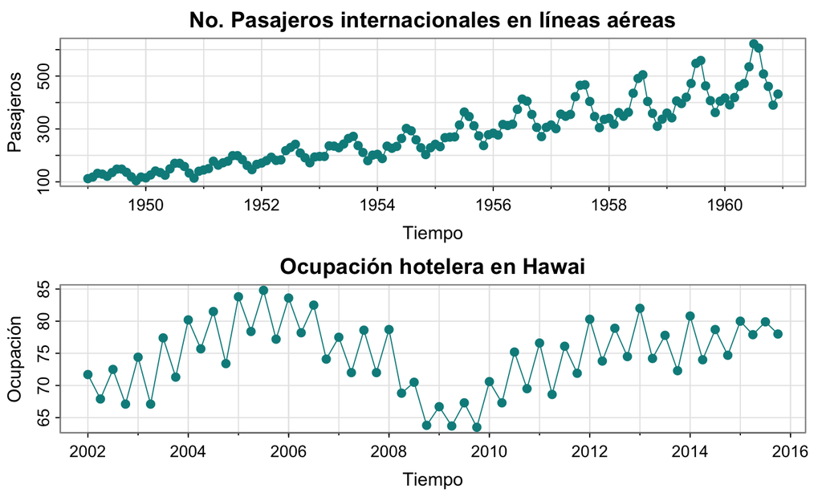

## Estacionariedad (4/4)

*Los modelos con patrón estacional violan directamente la condición de estacionariedad*, esto es debido a que:

\[ \mathbb{E}(y_t) = \mu_s \]

donde \(s\) indica la estación (mes, trimestre, etc.)

## Incorporación del componente estacional en el modelo (1/3)

El componente de la serie de tiempo que representa la variabilidad en los datos debida a influencias de las estaciones, se llama **componente estacional**. Existen dos formas diferentes para incorporar este componente en el modelo:

- **Componente determinista**. Incorporamos *explícitamente* en el modelo un patrón estacional.
- **Componente estocástico**. El patrón estacional proviene de una *raíz unitaria estacional*.

## Incorporación del componente estacional en el modelo (2/3)

Componente determinista vs. Componente estocástico

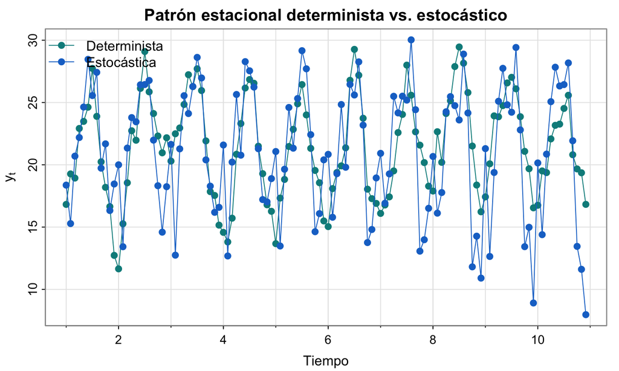

## Incorporación del componente estacional en el modelo (3/3)

Aunque los dos tipos de componente estacional son visualmente parecidos, las implicaciones teóricas y prácticas son diferentes:

- En un modelo con componente estacional determinista, los shocks tienen *efectos transitorios*. En un modelo con componente estacional estocástico, los shocks tienen *efectos persistentes*.
- El procedimiento para *remover* el componente estacional y hacer la serie estacionaria es distinto para cada caso.

## Componente estacional determinista

## Componente estacional determinista

Las siguientes series muestran un patrón estacional muy claro:

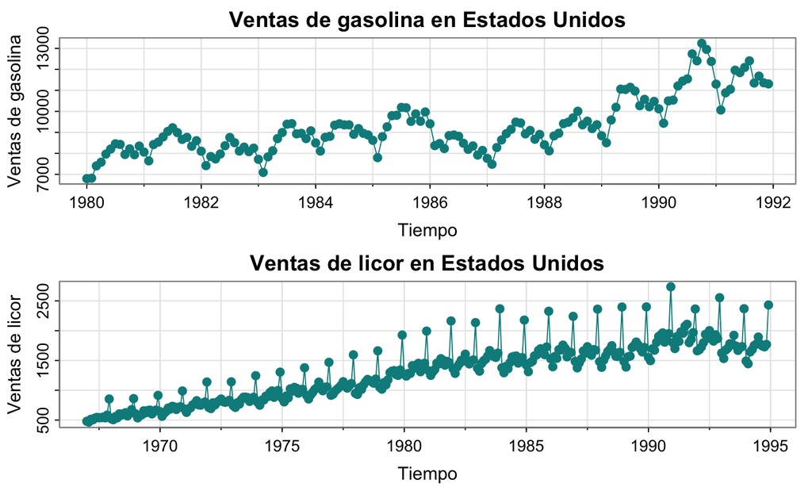

## Modelo estacional puro (1/2)

Para incorporar el componente estacional determinista en el modelo, supongamos que \(s\) es el número de estaciones en un año. Debemos construir un conjunto de \(s\) **variables dummy estacionales**. Por ejemplo, si \(s = 4\) (datos trimestrales):

\[ \begin{align} D_1 &= \begin{pmatrix} 1 & 0 & 0 & 0 & 1 & 0 & 0 & 0 & 1 & \dots \end{pmatrix}\\ D_2 &= \begin{pmatrix} 0 & 1 & 0 & 0 & 0 & 1 & 0 & 0 & 0 & \dots \end{pmatrix}\\ D_3 &= \begin{pmatrix} 0 & 0 & 1 & 0 & 0 & 0 & 1 & 0 & 0 & \dots \end{pmatrix}\\ D_4 &= \begin{pmatrix} 0 & 0 & 0 & 1 & 0 & 0 & 0 & 1 & 0 & \dots \end{pmatrix}\\ \end{align} \]

## Modelo estacional puro (2/3)

El **modelo estacional puro** es:

\[ y_t = \sum_{i=1}^s \gamma_i D_{it} + \varepsilon_t \]

Básicamente, tenemos un modelo en el que el intercepto es diferente en cada estación. Los coeficientes \(\gamma_i\) se conocen como **factores estacionales**.

*Nota*. Como siempre, debemos tener cuidado de no caer en la *trampa de las dummies*.

## Modelo estacional con tendencia (1/2)

También podemos incluir una *tendencia determinista* en un modelo estacional. Por ejemplo, si aumentamos el modelo estacional puro con una tendencia lineal tenemos:

\[ y_t = \beta_1 t + \sum_{i=1}^s \gamma_i D_{it} + \varepsilon_t \] También es posible tener modelos más complejos:

\[ y_t = \beta_1 t + \sum_{i=1}^s \gamma_i D_{it} + \sum_{i=1}^{\nu_1} \delta_i^{HD} HDV_{it} + \sum_{i=1}^{\nu_2} \delta_i^{TD} TDV_{it} + \varepsilon_t \]

donde \(HDV\) representa periodos de fiesta relevantes, y \(TDV\) son periodos de comercio relevantes. Estas también son variables dummy.

*Los estimadores de los coeficientes de todos estos modelos pueden obtenerse por MCO.*

## Modelo estacional con tendencia (2/2)

Por ejemplo, considera las ventas de gasolina en Estados Unidos (en dólares):

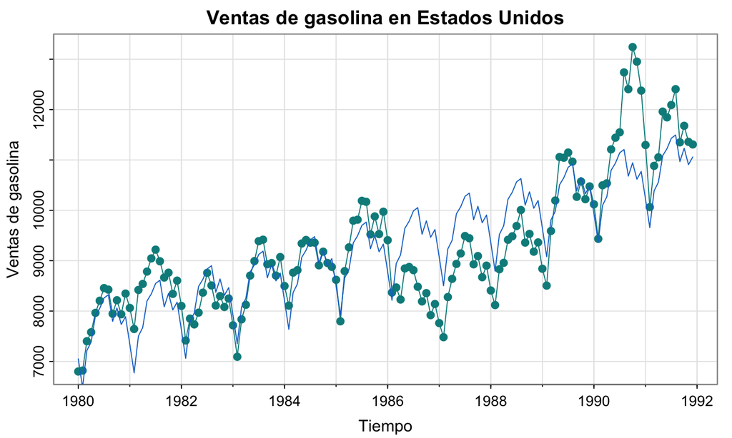

## Ejercicio (1/4)

Ejercicio

Considera el modelo:

\[ y_t = \sum_{i=1}^s \gamma_i D_{it} + \varepsilon_t \]

Muestra que \(y_t\) no es estacionario.

## Ejercicio (2/4)

Nota

Considera el modelo:

\[ y_t = \sum_{i=1}^s \gamma_i D_{it} + \varepsilon_t \]

Una forma de hacer que este modelo sea estacionario, consiste en calcular:

\[ \begin{align} y_t^\ast &= y_t - \sum_{i=1}^s \gamma_i D_{it} \\ & = \varepsilon_t \end{align} \]

Esta transformación puede hacerse operacional reemplazando los \(\gamma_i\) por sus estimadores de MCO.

## Ejercicio (3/4)

Ejercicio

A diferencia de los modelos con tendencia, aplicar diferencias a un modelo con componente estacional no hace que la serie de tiempo sea estacionaria. Por ejemplo, considera el modelo:

\[ y_t = \sum_{i=1}^s \gamma_i D_{it} + \varepsilon_t \]

Muestra que \(\Delta y_t\) no es estacionario.

## Ejercicio (4/4)

Ejercicio

Considera el modelo con datos trimestrales (\(s=4\)):

\[ y_t = \sum_{i=1}^4 \gamma_i D_{it} + \varepsilon_t \]

Muestra que \(\Delta^4 y_t = y_t - y_{t-4}\) es estacionario. Este es un ejemplo de modelos **ARIMA estacionales**, también conocidos como modelos **SARIMA**.

Nota. Los modelos SARIMA nos permiten tratar la **estacionalidad estocástica**, la cual ocurre cuando *el patrón estacional no es constante sino que evoluciona en el tiempo*.

## Ejemplo

Ejemplo

Las técnicas habituales para analizar y pronosticar series de tiempo, aplican también para los modelos con componente estacional (ver modelos ARMA). Por ejemplo, para las ventas de gasolina en Estados Unidos (en dólares) tenemos:

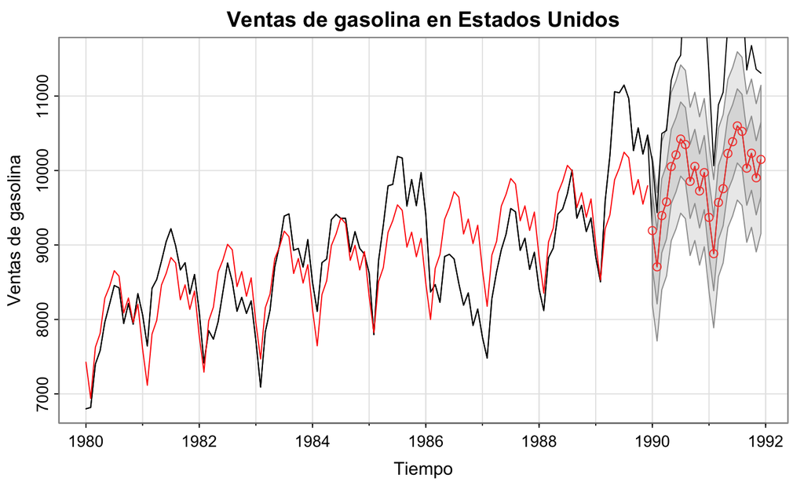

## Componente estacional estocástico: Modelos SARMA

## Componente estacional estocástico

Sea \(y_t\) una serie de tiempo que presenta un patrón estacional estocástico. En este caso, la dependencia serial no ocurre en todos los retardos, sino en aquellos que son múltiplos de \(s\). Por ejemplo:

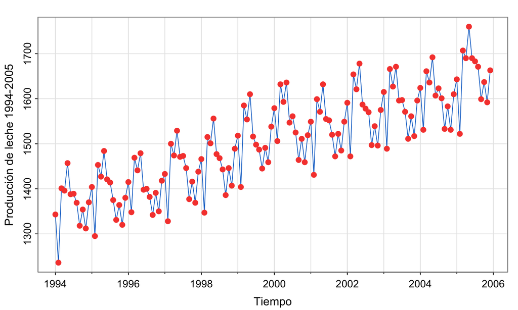

## Modelo \(MA(Q)_{s}\)

Una serie de tiempo, \(y_t\) sigue un proceso MA estacional (SMA) de orden \(Q,s\) o \(MA(Q)_s\) si:

\[ \begin{align} y_t &= \varepsilon_{t} + \Theta_1\varepsilon_{t-s} + \Theta_2\varepsilon_{t-2s}+\dots+ \Theta_Q\varepsilon_{t-Qs};\\ \varepsilon_{t} &\sim iid(0,\sigma^2) \end{align} \]

## Modelo \(MA(1)_{12}\) (1/4)

Por ejemplo, sean \(Q=1\) y \(s=12\). Entonces:

\[ y_t = \varepsilon_{t} + \Theta_1\varepsilon_{t-12} \]

En este caso, se puede demostrar que:

\[ \begin{align} \mu &= \mathbb{E}(y_t)\\ &=0 \end{align} \]

## Modelo \(MA(1)_{12}\) (2/4)

Además:

\[ \gamma_k = \begin{cases} (1+\Theta_1^2)\sigma^2 & \text{si } k=0\\ \Theta_1\sigma^2 & \text{si } k=12\\ 0 & \text{de otra forma }\\ \end{cases} \qquad \rho_k = \begin{cases} 1 & \text{si } k=0\\ \frac{\Theta_1}{1+\Theta_1^2} & \text{si } k=12\\ 0 & \text{de otra forma }\\ \end{cases} \]

Entonces, un proceso \(MA(1)_{12}\) es estacionario.

## Modelo \(MA(1)_{12}\) (3/4)

Los siguientes datos simulan un proceso \(MA(1)_{12}\):

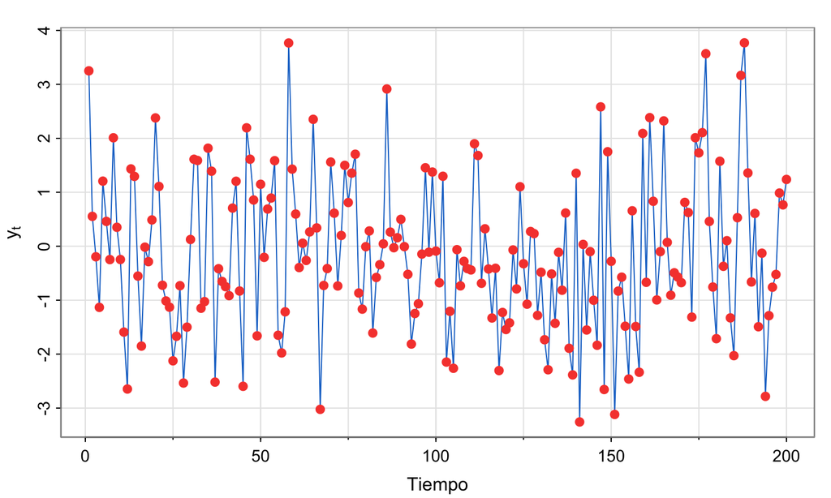

Nota que este proceso es equivalente a un \(MA(12)\) con \(\theta_1=\theta_2=\dots=\theta_11=0\).

## Modelo \(MA(1)_{12}\) (4/4)

Para este proceso tenemos:

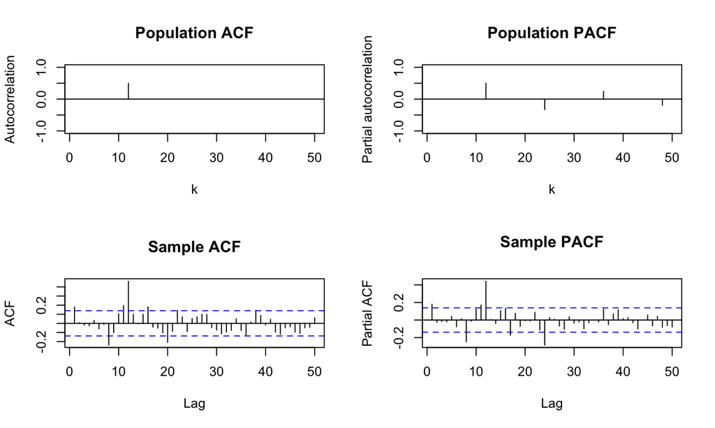

## Modelo \(MA(2)_{12}\) (1/2)

Ahora, sean \(Q=2\) y \(s=12\). Entonces:

\[ y_t = \varepsilon_{t} + \Theta_1\varepsilon_{t-12} + \Theta_2\varepsilon_{t-24} \]

Se puede demostrar que:

\[ \begin{align} \mu &= \mathbb{E}(y_t)\\ &=0 \end{align} \]

## Modelo \(MA(2)_{12}\) (2/2)

Además:

\[ \gamma_k = \begin{cases} (1+\Theta_1^2+\Theta_2^2)\sigma^2 & \text{si } k=0\\ (\Theta_1+\Theta_1\Theta_2)\sigma^2 & \text{si } k=12\\ \Theta_2\sigma^2 & \text{si } k=24\\ 0 & \text{de otra forma }\\ \end{cases} \qquad \rho_k = \begin{cases} 1 & \text{si } k=0\\ \frac{\Theta_1+\Theta_1\Theta_2}{1+\Theta_1^2+\Theta_2^2} & \text{si } k=12\\ \frac{\Theta_2}{1+\Theta_1^2+\Theta_2^2} & \text{si } k=24\\ 0 & \text{de otra forma }\\ \end{cases} \]

Nota que este proceso es equivalente a un \(MA(24)\) con \(\theta_1=\theta_2=\dots=\theta_{11}=\theta_{13}, \theta_{14}, \dots,\theta_{23} =0\).

## Modelo \(AR(P)_{s}\)

Una serie de tiempo, \(y_t\) sigue un proceso AR estacional (SAR) de orden \(P,s\) o \(AR(P)_s\) si:

\[ \begin{align} y_t &= \Phi_1 y_{t-s} + \Phi_2 y_{t-2s} + \dots + \Phi_P y_{t-Ps} + \varepsilon_{t};\\ \varepsilon_{t} &\sim iid(0,\sigma^2) \end{align} \]

## Modelo \(AR(1)_{12}\) (1/4)

Por ejemplo, sea \(P = 1\) y \(s = 12\). Entonces:

\[ y_t = \Phi_1 y_{t-s} + \varepsilon_{t}; \quad |\Phi_1|<1 \]

En este caso, se puede demostrar que:

\[ \begin{align} \mu &= \mathbb{E}(y_t)\\ &=0 \end{align} \]

## Modelo \(AR(1)_{12}\) (2/4)

Además:

\[ \gamma_0 = \frac{\sigma^2}{1-\Phi_1^2} \]

y:

\[ \rho_k = \begin{cases} \Phi_1^{k/12} & \text{si } k= 0, 12, 24, \dots \\ 0 & \text{de otra forma } \end{cases} \]

## Modelo \(AR(1)_{12}\) (3/4)

Los siguientes datos simulan un proceso \(AR(1)_{12}\):

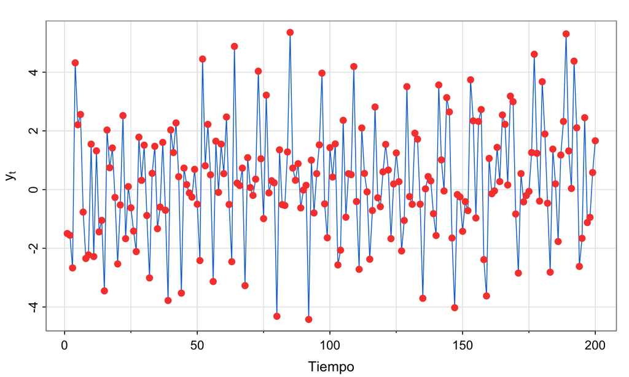

Nota que este proceso es equivalente a un \(AR(12)\) con \(\phi_1=\phi_2=\dots=\phi_11=0\).

## Modelo \(AR(1)_{12}\) (4/4)

Para este proceso tenemos:

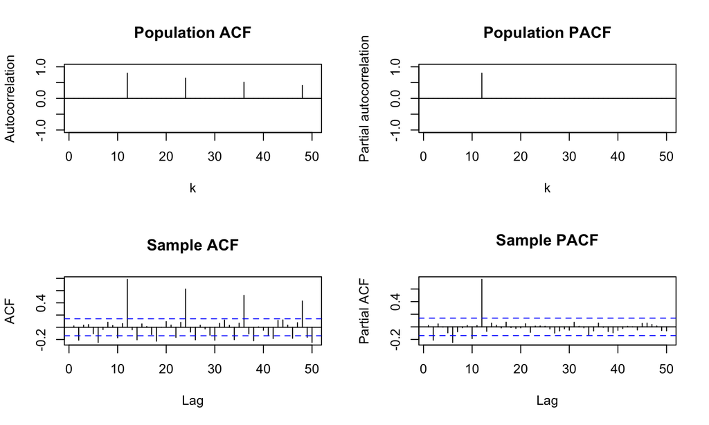

## Modelo \(AR(2)_{12}\)

Para un proceso \(AR(2)_{12}\) se pede demostrar que:

- La función de autocorrelación decrece exponencialmente u oscilatoriamente en los retardos: \(k=12, 24, 36, 48, \dots\)
- La función de autocorrelación parcial es diferente de cero en los retardos \(k=12\) y \(k=24\). Es cero en todos los demás valores de \(k\).
- Un proceso \(AR(2)_{12}\) es equivalente a un \(AR(24)\) con \(\phi_1=\phi_2=\dots=\phi_{11}=\phi_{13}, \phi_{14}, \dots,\phi_{23} =0\).

## Modelo \(ARMA(P,Q)_{s}\) (1/2)

Una serie de tiempo, \(y_t\) sigue un proceso ARMA estacional (SARMA) de orden \(P,Q, s\) o \(ARMA(P,Q)_s\) si:

\[ \begin{align} y_t &= \Phi_1 y_{t-s} + \Phi_2 y_{t-2s} + \dots + \Phi_P y_{t-Ps} + \varepsilon_{t} + \Theta_1\varepsilon_{t-s} + \Theta_2\varepsilon_{t-2s}+\dots+ \Theta_Q\varepsilon_{t-Qs};\\ \varepsilon_{t} &\sim iid(0,\sigma^2) \end{align} \]

## Modelo \(ARMA(P,Q)_{s}\) (2/2)

Un proceso \(ARMA(P,Q)_{s}\):

- Es equivalente a un \(ARMA(p,q)\) con autocorrelaciones diferentes de cero en los retardos \(k=s, 2s, 3s, \dots\).
- Es estacionario si y solo si las raíces del polinomio \(\boldsymbol{\Phi}_P(L^s)=0\) se encuentran *fuera del círculo unitario*.
- Es invertible si y solo si las raíces del polinomio \(\boldsymbol{\Theta}_Q(L^s)=0\) se encuentran *fuera del círculo unitario*.

## Modelos SARMA Multiplicativos

## Modelos SARMA Multiplicativos

Un proceso con componente estacional multiplicativo implica, como su nombre lo indica, multiplicar un proceso ARMA(\(p,q\)) por un proceso SARMA(\(P,Q\))_{s}.

## ARMA(\(p,q\)) x ARMA(\(P,Q\))_{s}

## ARMA(\(p,q\)) x ARMA(\(P,Q\))_{s}: Ejemplo (1/3)

Los datos se encuentran en escala logarítmica.

## Modelos SARIMA: Ejemplo (2/3)

- ARIMA (0,1,0) x ARIMA (0,1,1)_{12}
- ARIMA (0,1,0) x ARIMA (3,1,0)_{12}

¿Por qué?